# Análisis estadístico de las condiciones ambientales y los factores de concurrencia en las distintas áreas del campus UTEC en el ciclo 2026-1

#### Paso 4: Propiedades de la distribución teórica

```r
E_bin   <- n_bin * p_bin
Var_bin <- n_bin * p_bin * (1 - p_bin)
SD_bin  <- sqrt(Var_bin)

data.frame(
  Propiedad = c("Esperanza: E(X)", "Varianza: Var(X)", "Desviación estándar: SD(X)"),
  Valor     = round(c(E_bin, Var_bin, SD_bin), 4)
)
```

```
                   Propiedad  Valor
1            Esperanza: E(X) 7.1630
2           Varianza: Var(X) 3.7424
3 Desviación estándar: SD(X) 1.9345
```

**Interpretación:** En promedio, se espera que 7.16 de 15 estudiantes seleccionados al azar reporten facilidad alta para estudiar. La desviación estándar de 1.9 indica variabilidad moderada.

#### Paso 5: Respuesta al caso

**Pregunta planteada:** ¿Cuál es la probabilidad de que exactamente **6 de los 15** estudiantes seleccionados reporten facilidad alta (niveles 4 o 5)?

$$P(X = 6) = \binom{15}{6} p^6 (1-p)^{9}$$

```r
# Responder el caso: P(X = 6)
p_caso2_puntual <- dbinom(6, size = n_bin, prob = p_bin)
cat("P(X = 6) =", round(p_caso2_puntual, 6), "\n")
```

```
P(X = 6) = 0.17217
```

**Interpretación:** Existe una probabilidad de aproximadamente **17.21%** de que exactamente 6 de los 15 estudiantes seleccionados al azar reporten facilidad alta para estudiar.

#### Paso 6: Ejemplo de distribución acumulada

**Pregunta:** ¿Cuál es la probabilidad de que **10 o más** estudiantes de los 15 seleccionados reporten facilidad alta?

$$P(X \ge 10) = 1 - P(X \le 9)$$

```r
# P(X >= 10) usando cola derecha con lower.tail = FALSE
p_caso2_acum <- pbinom(9, size = n_bin, prob = p_bin, lower.tail = FALSE)
cat("P(X ≥ 10) =", round(p_caso2_acum, 6), "\n")
```

```
P(X ≥ 10) = 0.113356
```

**Interpretación:** Solo existe una probabilidad de **11.34%** de que 10 o más estudiantes de los 15 seleccionados reporten facilidad alta para estudia.

### IV.3.2 Variables aleatorias continuas

#### Caso 1 – Nivel de presión sonora (dB)

#### Paso 1: Selección de la variable

La variable seleccionada es el **Nivel de presión sonora (dB)**.

#### Paso 2: Validación del ajuste a distribuciones continuas

```r
dB_vec <- na.omit(DF_Final$`Nivel de presión sonora (dB)`)
mu_dB  <- mean(dB_vec)
sd_dB  <- sd(dB_vec)
me_dB  <- median(dB_vec)
n_dB   <- length(dB_vec)

cat(" Estadísticos empíricos  Presión sonora (dB)")
```

```
 Estadísticos empíricos  Presión sonora (dB)
```

```r
cat("Media:         ", round(mu_dB, 4), "\n")
```

```
Media:          115.044
```

```r
cat("Mediana:       ", round(me_dB, 4), "\n")
```

```
Mediana:        128.29
```

```r
cat("Desv. estándar:", round(sd_dB, 4), "\n")
```

```
Desv. estándar: 37.0582
```

```r
cat("Mínimo:        ", round(min(dB_vec), 4), "\n")
```

```
Mínimo:         30
```

```r
cat("Máximo:        ", round(max(dB_vec), 4), "\n")
```

```
Máximo:         166.6
```

```r
cat("n:             ", n_dB, "\n")
```

```
n:              1669
```

**Evidencia gráfica:**

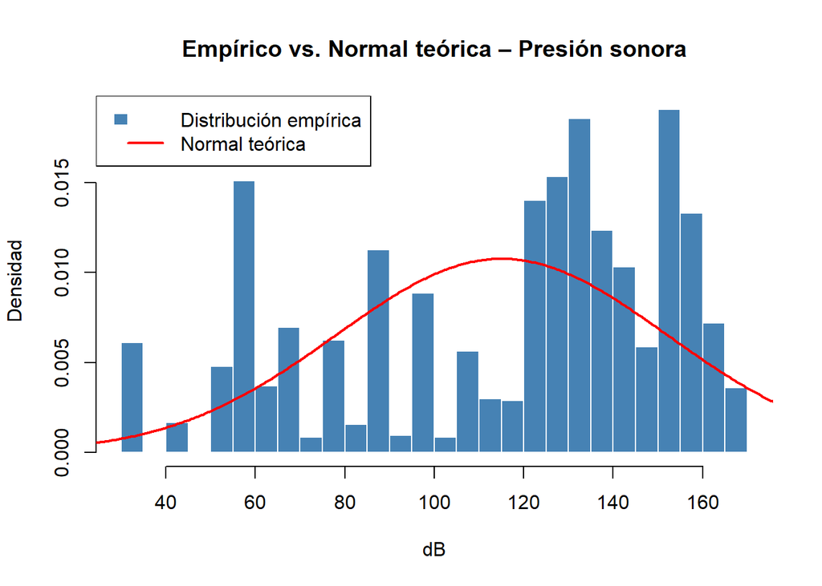

```r
x_dB <- seq(min(dB_vec)-10, max(dB_vec)+10, length.out=300)
hist(dB_vec, freq=FALSE, main="Empírico vs. Normal teórica – Presión sonora",
     xlab="dB", ylab="Densidad", col="steelblue", border="white", breaks=20)
lines(x_dB, dnorm(x_dB, mean=mu_dB, sd=sd_dB), col="red", lwd=2)
legend("topleft", legend=c("Distribución empírica","Normal teórica"),
       fill=c("steelblue",NA), lty=c(NA,1), col=c(NA,"red"), lwd=c(NA,2), border=c("white",NA))
```

**Evidencia numérica Comparación de propiedades teóricas vs. empíricas:**

```r
# Normal: media ≈ mediana
asimetria_dB <- (mu_dB - me_dB) / sd_dB

# Exponencial: media ≈ desv. estándar (razón ≈ 1)
razon_exp_dB <- sd_dB / mu_dB

# Uniforme: media ≈ (min + max) / 2
media_unif_esp_dB <- (min(dB_vec) + max(dB_vec)) / 2

data.frame(
  Distribución     = c("Normal", "Exponencial", "Uniforme"),
  `Propiedad clave` = c(
    "Media ≈ Mediana entonces asimetría de Pearson ≈ 0",
    "Media ≈ Desv. estándar entonces razón ≈ 1",
    "Media ≈ (mín + máx) / 2"
  ),
  `Valor teórico` = c("0", "1", round(media_unif_esp_dB, 2)),
  `Valor empírico` = c(
    round(asimetria_dB, 4),
    round(razon_exp_dB, 4),
    round(mu_dB, 2)
  ),
  `¿Se ajusta?` = c("No", "No", "No"),
  check.names = FALSE
)
```

```
  Distribución                                   Propiedad clave Valor teórico
1       Normal Media ≈ Mediana entonces asimetría de Pearson ≈ 0             0
2  Exponencial         Media ≈ Desv. estándar entonces razón ≈ 1             1
3     Uniforme                           Media ≈ (mín + máx) / 2          98.3
  Valor empírico ¿Se ajusta?
1        -0.3574          No
2         0.3221          No
3       115.0400          No
```

**Conclusión del ajuste:** El histograma revela una distribución bimodal (ambientes silenciosos y ruidosos), impidiendo el ajuste a distribuciones continuas unimodales; modelar dos picos reales requiere combinar dos distribuciones.

Para el siguiente ejemplo, se supone normalidad.

#### Paso 3: Propiedades de la distribución teórica (supuesto Normal)

```r
mu_sup  <- mu_dB
sig_sup <- sd_dB

data.frame(
  Propiedad = c(
    "Parámetro μ (media)",
    "Parámetro σ (desv. estándar)",
    "Esperanza   E[X] = μ",
    "Varianza    Var[X] = σ²",
    "Desv. est.  SD[X] = σ"
  ),
  Valor = round(c(mu_sup, sig_sup, mu_sup, sig_sup^2, sig_sup), 2)
)
```

```
                     Propiedad   Valor
1          Parámetro μ (media)  115.04
2 Parámetro σ (desv. estándar)   37.06
3         Esperanza   E[X] = μ  115.04
4      Varianza    Var[X] = σ² 1373.31
5        Desv. est.  SD[X] = σ   37.06
```

#### Paso 4: Ejemplo con distribución acumulada

Dado que $X \sim \mathcal{N}(\mu = 115.04,\ \sigma = 37.06)$:

**Pregunta:** ¿Cuál es la probabilidad de que una medición de presión sonora seleccionada al azar se encuentre entre **90 y 140 dB**?

$$P(90 < X < 140) = P(X \le 140) - P(X \le 90)$$
$$= \texttt{pnorm}(140,\ 115.04,\ 37.06)\ -\ \texttt{pnorm}(90,\ 115.04,\ 37.06)$$

```r
p_ej_dB <- pnorm(140, mean = mu_sup, sd = sig_sup) -
           pnorm(90,  mean = mu_sup, sd = sig_sup)

cat("P(90 < X < 140) =", round(p_ej_dB, 4), "\n")
```

```
P(90 < X < 140) = 0.5001
```

**Interpretación:** Bajo el supuesto normal, existe una probabilidad de ~50% de que una medición caiga entre 90 y 140 dB. Al ser la distribución real bimodal y no normal, este resultado es solo ilustrativo.

#### Caso 2 – Nivel de iluminancia (lux)

#### Paso 1: Selección de la variable

La segunda variable seleccionada es el **Nivel de iluminancia (lux)**.

#### Paso 2: Validación del ajuste a distribuciones continuas

```r
lux_vec <- na.omit(DF_Final$`Nivel de iluminancia`)
mu_lux  <- mean(lux_vec)
sd_lux  <- sd(lux_vec)
me_lux  <- median(lux_vec)
n_lux   <- length(lux_vec)

cat("Estadísticos empíricos  Iluminancia (lux)\n")
```

```
Estadísticos empíricos  Iluminancia (lux)
```

```r
cat("Media:         ", round(mu_lux, 4), "\n")
```

```
Media:          326.8929
```

```r
cat("Mediana:       ", round(me_lux, 4), "\n")
```

```
Mediana:        234.56
```

```r
cat("Desv. estándar:", round(sd_lux, 4), "\n")
```

```
Desv. estándar: 385.7603
```

```r
cat("Mínimo:        ", round(min(lux_vec), 4), "\n")
```

```
Mínimo:         0.072
```

```r
cat("Máximo:        ", round(max(lux_vec), 4), "\n")
```

```
Máximo:         1978.87
```

```r
cat("n:             ", n_lux, "\n")
```

```
n:              1669
```

**Evidencia gráfica:**

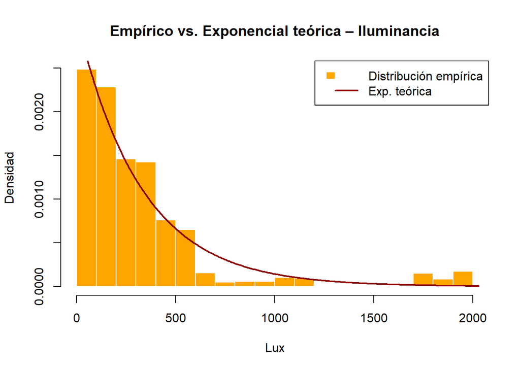

```r
lambda_lux <- 1/mu_lux
x_lux <- seq(0, max(lux_vec)+50, length.out=300)
hist(lux_vec, freq=FALSE, main="Empírico vs. Exponencial teórica – Iluminancia",
     xlab="Lux", ylab="Densidad", col="orange", border="white", breaks=20)
lines(x_lux, dexp(x_lux, rate=lambda_lux), col="darkred", lwd=2)
legend("topright", legend=c("Distribución empírica","Exp. teórica"),
       fill=c("orange",NA), lty=c(NA,1), col=c(NA,"darkred"), lwd=c(NA,2), border=c("white",NA))
```

**Evidencia numérica:**

```r
# Normal: media ≈ mediana
asimetria_lux <- (mu_lux - me_lux) / sd_lux

# Exponencial: media ≈ desv. estándar (razón ≈ 1)
# y mediana teórica = ln(2)/lambda = ln(2) * media ≈ 0.693 * media
razon_exp_lux  <- sd_lux / mu_lux
mediana_exp_te <- log(2) * mu_lux

# Uniforme: media ≈ (min + max) / 2
media_unif_lux <- (min(lux_vec) + max(lux_vec)) / 2

data.frame(
  Distribución     = c("Normal", "Exponencial", "Uniforme"),
  `Propiedad clave` = c(
    "Media ≈ Mediana entonces asimetría de Pearson ≈ 0",
    "Media ≈ Desv. estándar entonces razón ≈ 1  ;  Mediana ≈ ln(2) × Media",
    "Media ≈ (mín + máx) / 2"
  ),
  `Valor teórico` = c(
    "0",
    paste0("razón = 1  ;  mediana ≈ ", round(mediana_exp_te, 2)),
    round(media_unif_lux, 2)
  ),
  `Valor empírico` = c(
    round(asimetria_lux, 4),
    paste0("razón = ", round(razon_exp_lux, 4),
           "  ;  mediana = ", round(me_lux, 2)),
    round(mu_lux, 2)
  ),
  `¿Se ajusta?` = c("No", "Sí (aproximado)", "No"),
  check.names = FALSE
)
```

```
  Distribución
1       Normal
2  Exponencial
3     Uniforme
                                                        Propiedad clave
1                     Media ≈ Mediana entonces asimetría de Pearson ≈ 0
2 Media ≈ Desv. estándar entonces razón ≈ 1  ;  Mediana ≈ ln(2) × Media
3                                               Media ≈ (mín + máx) / 2
                   Valor teórico                      Valor empírico
1                              0                              0.2394
2 razón = 1  ;  mediana ≈ 226.58 razón = 1.1801  ;  mediana = 234.56
3                         989.47                              326.89
      ¿Se ajusta?
1              No
2 Sí (aproximado)
3              No
```

**Conclusión del ajuste:** La evidencia gráfica y numérica indica que se aproxima a una distribución Exponencial:

El histograma muestra alta concentración de valores bajos con cola derecha pronunciada, forma característica de la exponencial. La razón SD/Media ≈ 1.20 es próxima a 1 y la mediana empírica es cercana a la mediana teórica

$$X \sim \text{Exp}(\lambda)$$

#### Paso 3: Propiedades de la distribución teórica Exponencial

```r
lambda_lux <- 1 / mu_lux   # estimación por método de momentos

cat("Parámetro estimado: λ =", round(lambda_lux, 6), "\n\n")
```

```
Parámetro estimado: λ = 0.003059
```

```r
data.frame(
  Propiedad = c(
    "Parámetro λ (tasa)",
    "Esperanza: E[X] = 1/λ",
    "Varianza: Var[X] = 1/λ²",
    "Desv. est.: SD[X] = 1/λ"
  ),
  Fórmula = c("1 / media empírica", "1/λ", "1/λ²", "1/λ"),
  Valor   = round(c(lambda_lux, 1/lambda_lux, (1/lambda_lux)^2, 1/lambda_lux), 4)
)
```

```
                Propiedad            Fórmula       Valor
1      Parámetro λ (tasa) 1 / media empírica      0.0031
2   Esperanza: E[X] = 1/λ                1/λ    326.8929
3 Varianza: Var[X] = 1/λ²               1/λ² 106858.9774
4 Desv. est.: SD[X] = 1/λ                1/λ    326.8929
```

#### Paso 4: Ejemplo con distribución acumulada

**Pregunta:** ¿Cuál es la probabilidad de que la iluminancia se encuentre entre **100 y 400 lux**?

$$P(100 < X < 400) = P(X \le 400) - P(X \le 100)$$
$$= \texttt{pexp}(400,\ \lambda)\ -\ \texttt{pexp}(100,\ \lambda)$$

```r
p_ej_lux_rango <- pexp(400, rate = lambda_lux) - pexp(100, rate = lambda_lux)
cat("P(100 < X < 400 lux) =", round(p_ej_lux_rango, 4), "\n")
```

```
P(100 < X < 400 lux) = 0.4423
```

Interpretacion: Bajo el ajuste exponencial, existe aproximadamente un 44.23% de probabilidad de que la iluminancia se encuentre entre 100 y 400 lux. Esto indica que casi la mitad de los espacios medidos se concentra en ese rango de iluminación baja a media.

# V. Conclusiones